```r
library(tidyverse) #version 1.3.0
library(drc) #version 3.0-1
library(readxl) #version 1.3.1
library(ggplot2) #version 3.3.3

knitr::opts_chunk$set(warning=FALSE, message=FALSE)
```

# *C. elegans* plate experiment analysis

There is a lot of data in the file, but not always very logically ordered. There also seem to be quite a lot of missing data points.

For RawData and compConcentration, the expected data type is numeric. For compName, the expected data type is character.

```r
CE.LIQ.FLOW.062 <- read_excel(here::here("data/CE.LIQ.FLOW.062_Tidydata.xlsx")) ##importing file
inspect_columns <- CE.LIQ.FLOW.062 %>% dplyr::select(RawData, compName, compConcentration) ##selecting the columns
skimr::skim(inspect_columns) ##printing overview of the selected columns
```

Data summary

| Name | inspect_columns |
| --- | --- |
| Number of rows | 360 |
| Number of columns | 3 |
| _______________________ |  |
| Column type frequency: |  |
| character | 2 |
| numeric | 1 |
| ________________________ |  |
| Group variables | None |

**Variable type: character**

| skim_variable | n_missing | complete_rate | min | max | empty | n_unique | whitespace |
| --- | --- | --- | --- | --- | --- | --- | --- |
| compName | 0 | 1 | 6 | 26 | 0 | 5 | 0 |
| compConcentration | 0 | 1 | 1 | 21 | 0 | 16 | 0 |

**Variable type: numeric**

| skim_variable | n_missing | complete_rate | mean | sd | p0 | p25 | p50 | p75 | p100 | hist |
| --- | --- | --- | --- | --- | --- | --- | --- | --- | --- | --- |
| RawData | 5 | 0.99 | 68.1 | 26.85 | 0 | 51.5 | 72 | 88 | 124 | ▂▃▇▇▂ |

As shown in the overview, RawData and compName have been assigned their expected data types. compConcentration, however, has been assigned a character values. This means that not all data types have been correctly assigned during the importing of the file.

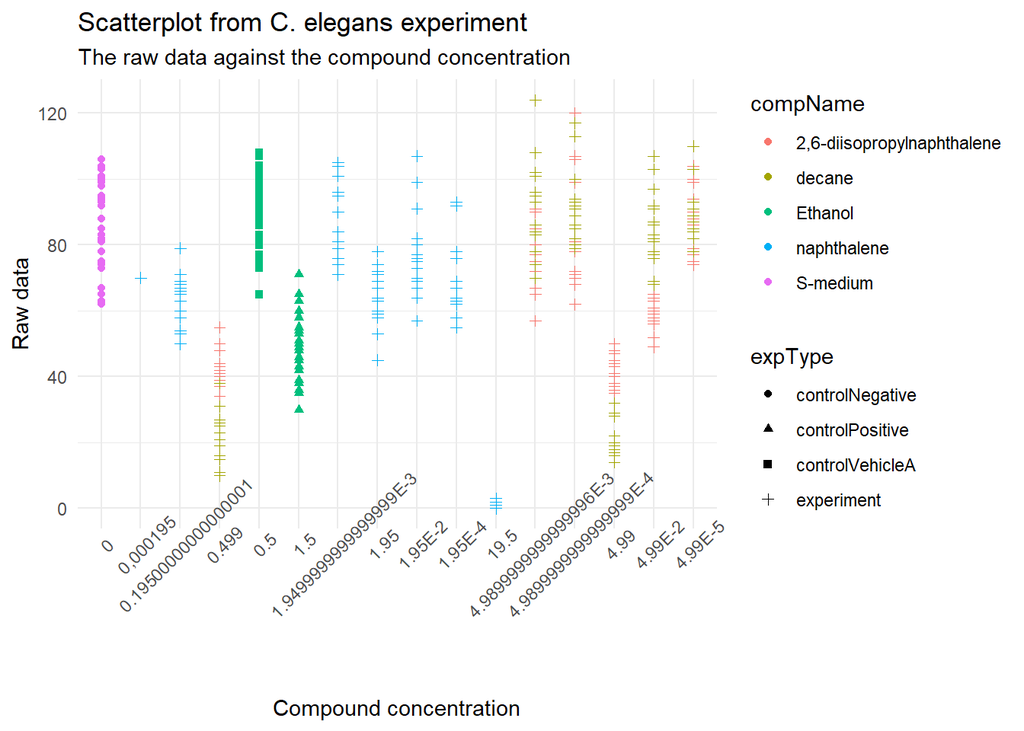

```r
CE.LIQ.FLOW.062 %>% ggplot() +
  geom_point(aes(x = compConcentration, y = RawData, colour = compName, shape = expType))+ theme_minimal() +
  theme(axis.text.x = element_text(angle=45)) +
  labs(title = "Scatterplot from C. elegans experiment",
       subtitle = "The raw data against the compound concentration",
       x = "Compound concentration",
       y = "Raw data")
```

The data type is ‘character’. Because of this, the x-axis variables are seen as strings instead of numbers and therefore can not scale them.

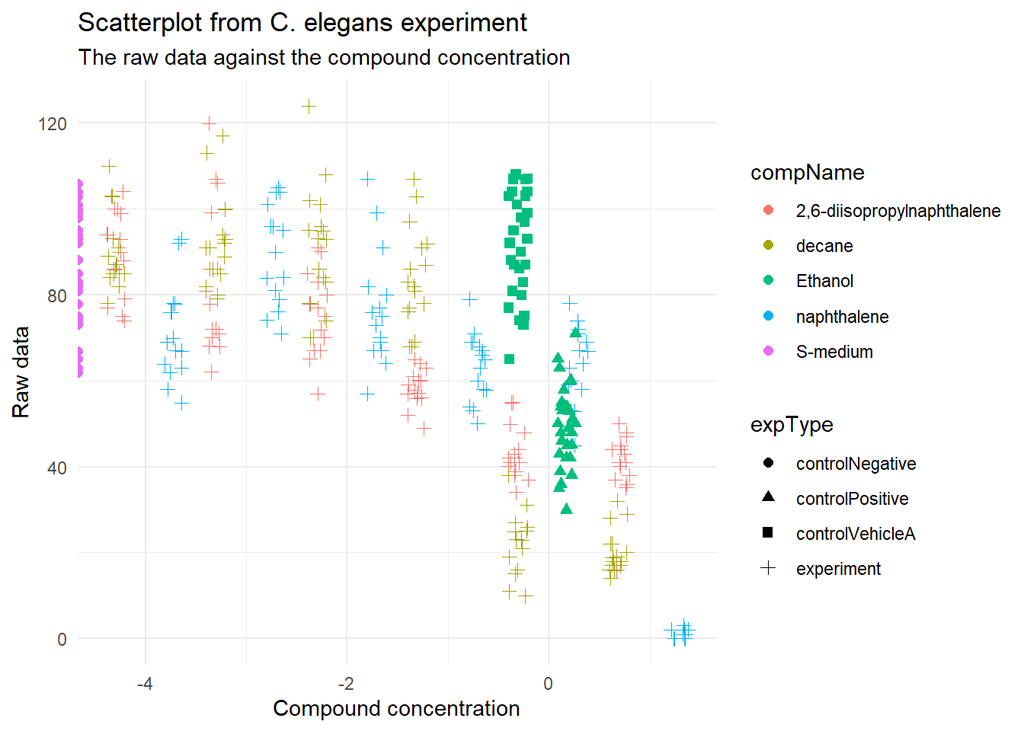

```r
CE.LIQ.FLOW.062$compConcentration <- gsub(",", ".", CE.LIQ.FLOW.062$compConcentration) ##replace , with . (for data point 259)
CE.LIQ.FLOW.062$compConcentration <- as.numeric(CE.LIQ.FLOW.062$compConcentration) ##assign correct data type

CE.LIQ.FLOW.062 %>% ggplot() +
  geom_point(aes(x = log10(compConcentration), y = RawData, colour = compName, shape = expType), position = position_jitter(width = 0.1, height = 0.1), size = 2) +
  labs(title = "Scatterplot from C. elegans experiment",
       subtitle = "The raw data against the compound concentration",
       x = "Compound concentration",
       y = "Raw data") +
  theme_minimal()
```

The positive control for this experiment is Ethanol. The negative control for this experiment is S-medium.

To analyze this experiment and learn wheter there is an effect of different concentrations on offspring count and wheter the different compounds have a different IC50 curve:

1. First, the mean of the different concentrations are calculated, per compound.
2. Then, these means are divided by the controlNegative mean to calculate the relative effect per compound per concentration.
3. When these relative values are plotted in a curve, the difference in IC50 (if any) will be shown.
4. Finally, there may be run some statistical tests to indicate whether there is a statistically significant difference between different curves.

```r
controlNegative <- CE.LIQ.FLOW.062 %>% filter(expType == "controlNegative")
cn_mean <- mean(controlNegative$RawData)
cn_mean / cn_mean
```

```
## [1] 1
```

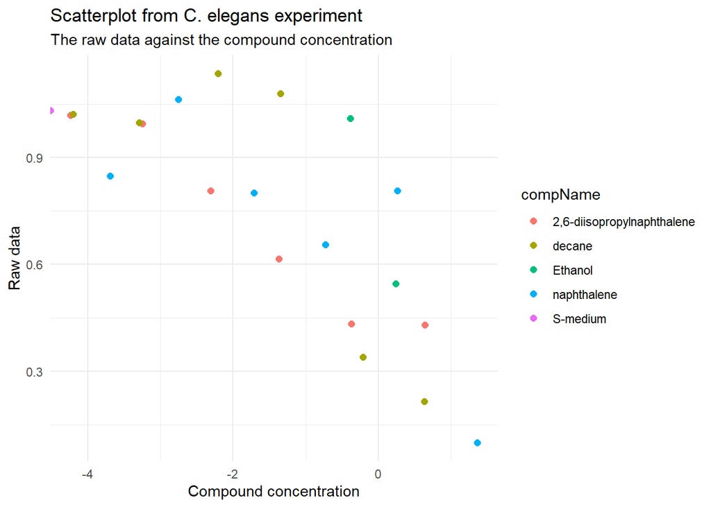

```r
means <- CE.LIQ.FLOW.062 %>% group_by(compName, compConcentration) %>% summarise(mean = mean(RawData, na.rm = TRUE))
means$relative <- means$mean / cn_mean

means %>% ggplot() +
  geom_point(aes(x = log10(compConcentration), y = relative, colour = compName), position = position_jitter(width = 0.1, height = 0.1), size = 2) +
  labs(title = "Scatterplot from C. elegans experiment",
       subtitle = "The raw data against the compound concentration",
       x = "Compound concentration",
       y = "Raw data") +
  theme_minimal()
```

By viewing the data relatively, it visualizes the differences and similarities between data points more accurately than when viewing them as raw data points.